# MOM6 Subsurface Heatwaves

## Purpose

Try to use MOM6 data to calculate subsurface heatwaves in the California Current, taking advantage of the new earthmover setup for data access.

## Import Data

Ocean heat content has been calculated separately in `calculate_ohc.R`. We calculated it across a bunch of depth bins: 0-5m, 0-50m, 50-100m, 100-250m, 250-500m, and 500-1000m depth.

Background polygon

## Calculate Anomalies

Calculate a monthly climatology. Crop everything to the eez

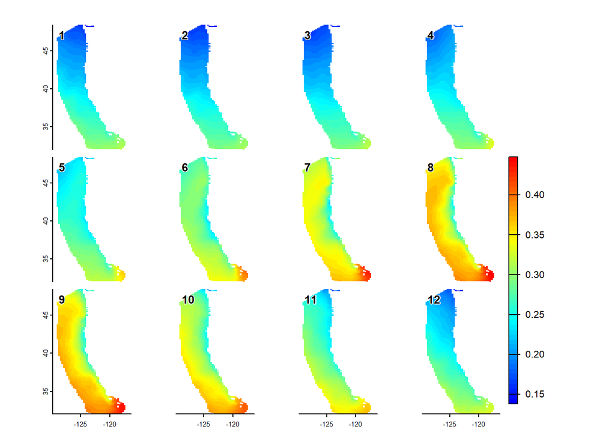

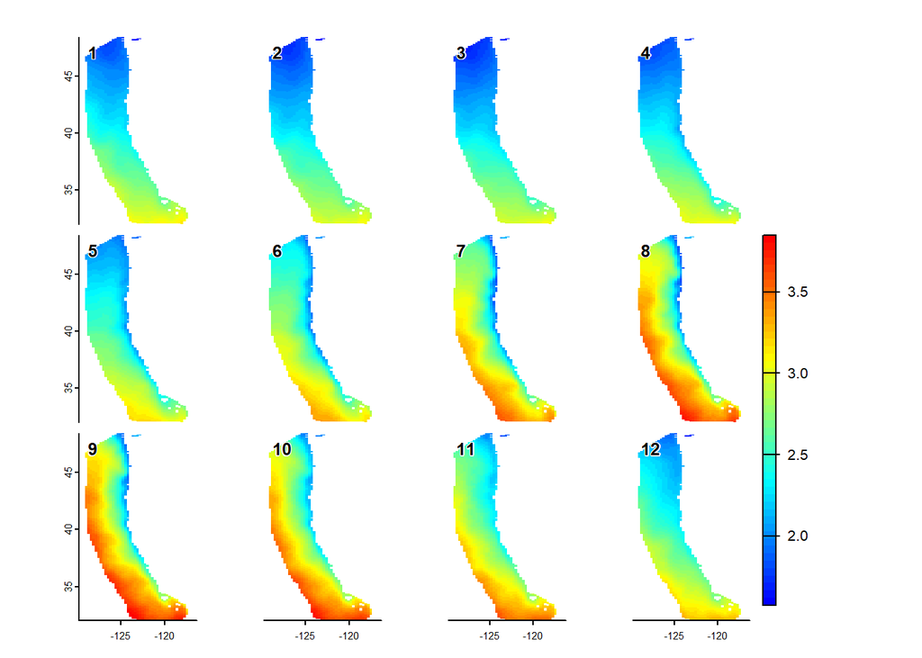

Try counting anomalies from these climatologies. We define anomaly as a z-score anomaly, that is, we substract the mean and divide by the standard deviation.

## Detrending

Let’s make de-trended versions of the rasters, removing any linear effect of time on the anomalies. This will help us distinguish, e.g., short term deviations (heatwaves) from long-term warming.

## Anomaly timeseries

Can we use this dataset to calculate a timeseries? First, a simple mean anomaly over time, averaging the anomaly values across all grid cells in a given time step and depth layer.

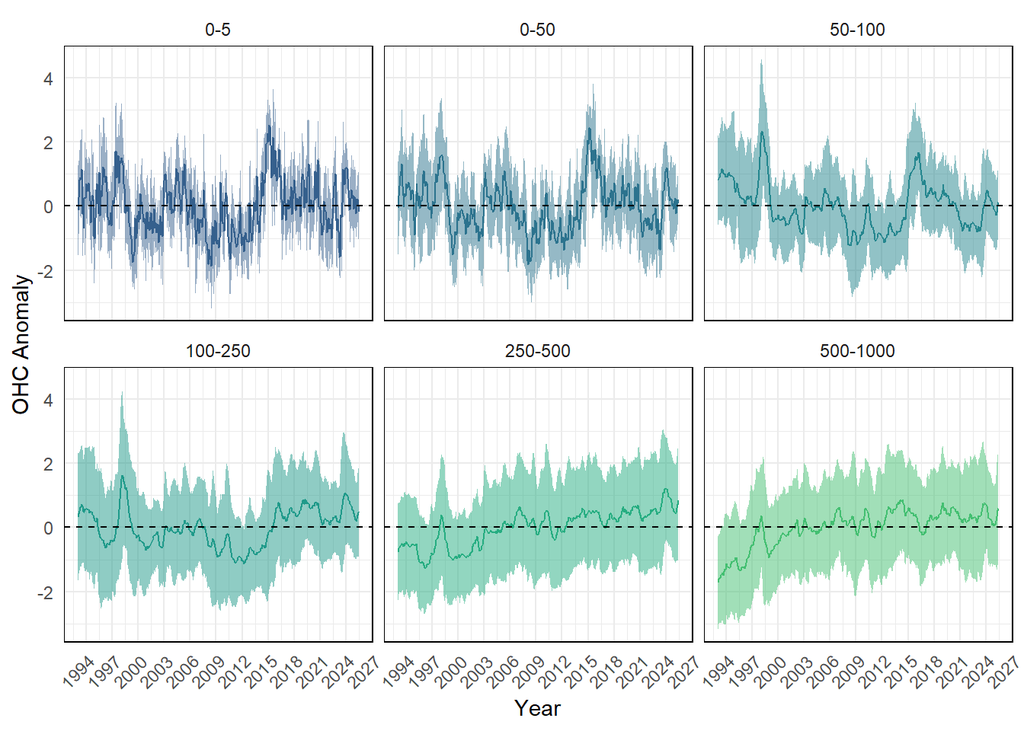

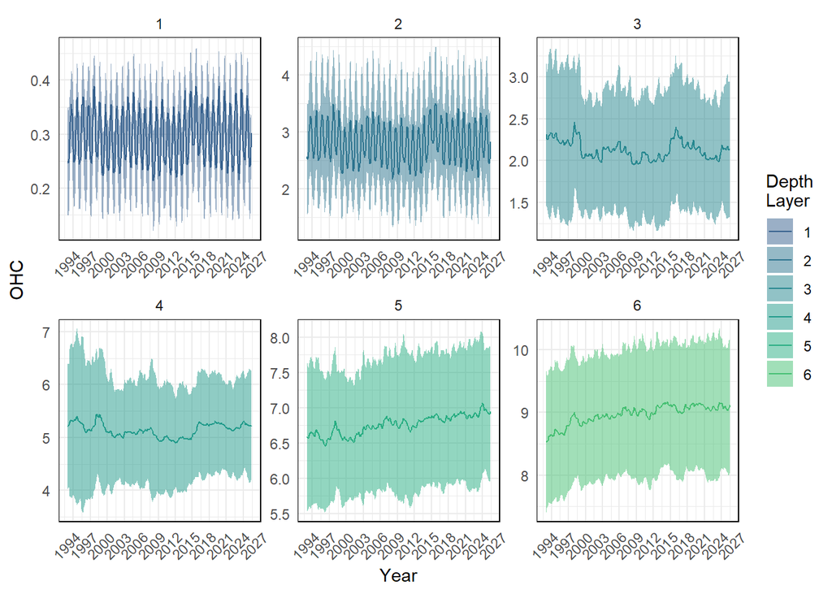

## By Latitude

We can also make time series by latitude bins, to assess any latitudinal differences in the timing or magnitude of ocean heat changes.

Or by HCI regions

Use the latitude bin template raster and `terra::zonal()` to calculate latitude-bin means for all depth layers.

Plot the time series by latitude bin.

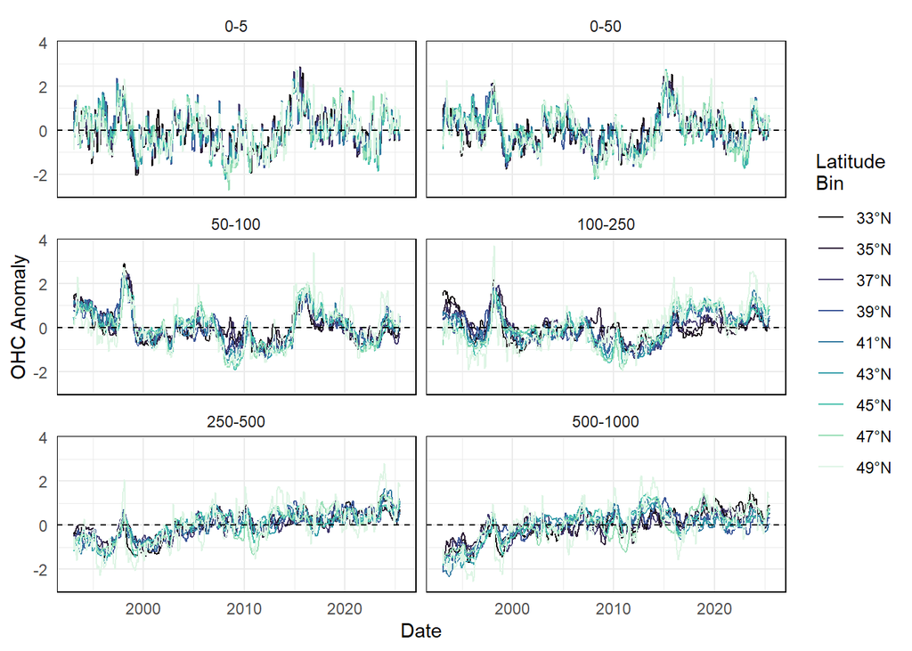

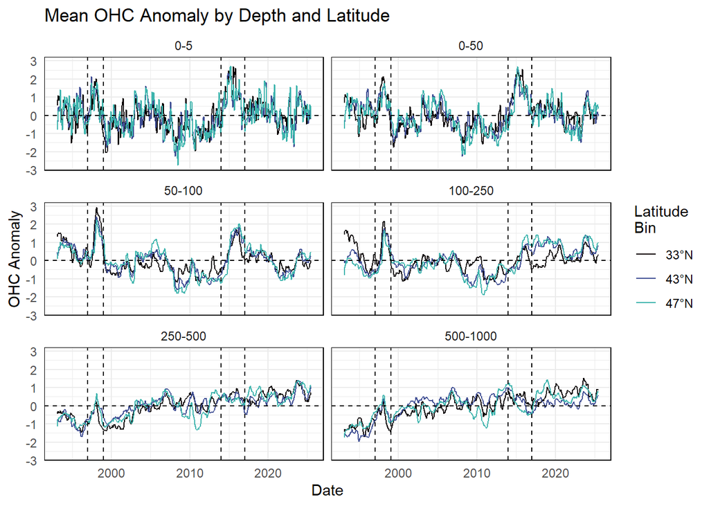

De-trended time series

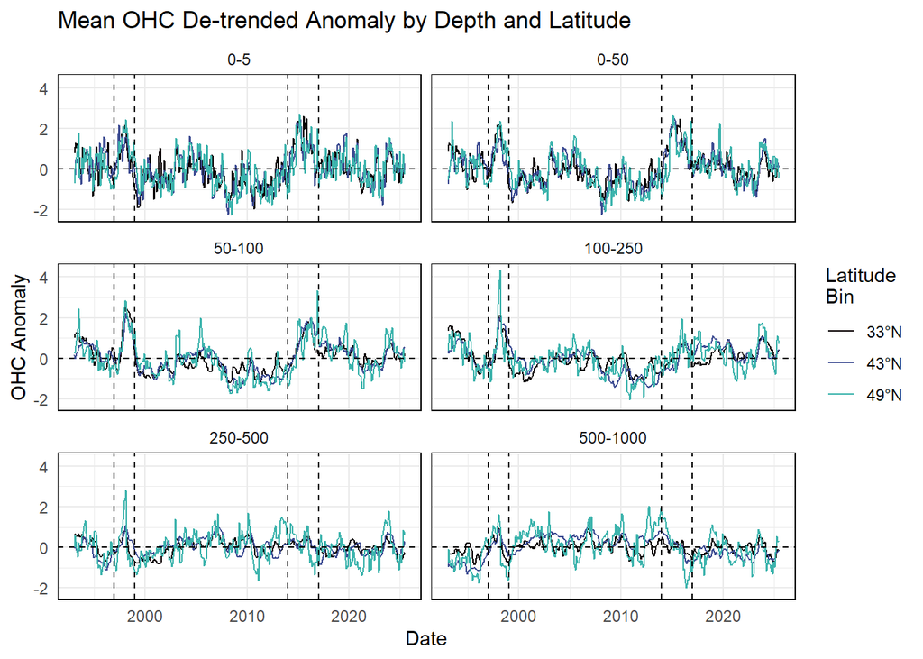

Hovmoller plots of this over time. These plots show the OHC time series by both time and latitude bin.

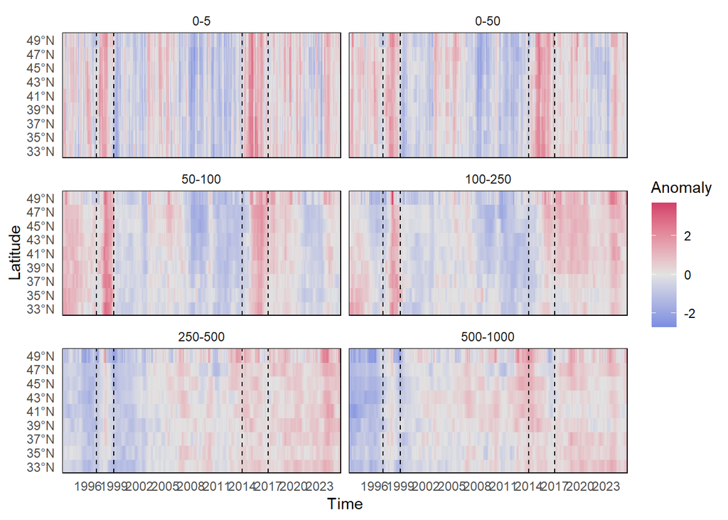

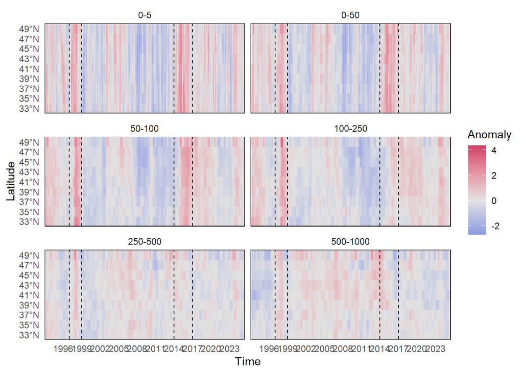

## By HCI Region

Use the HCI template raster and `terra::zonal()` to calculate HCI-region means for all depth layers.

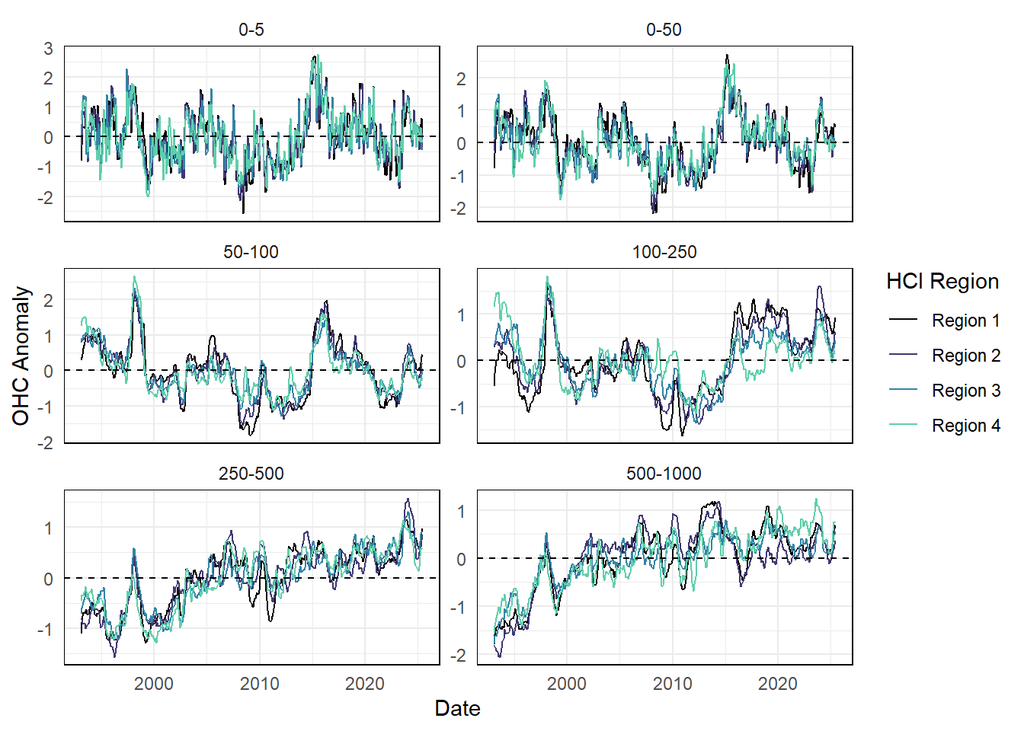

De-trended time series

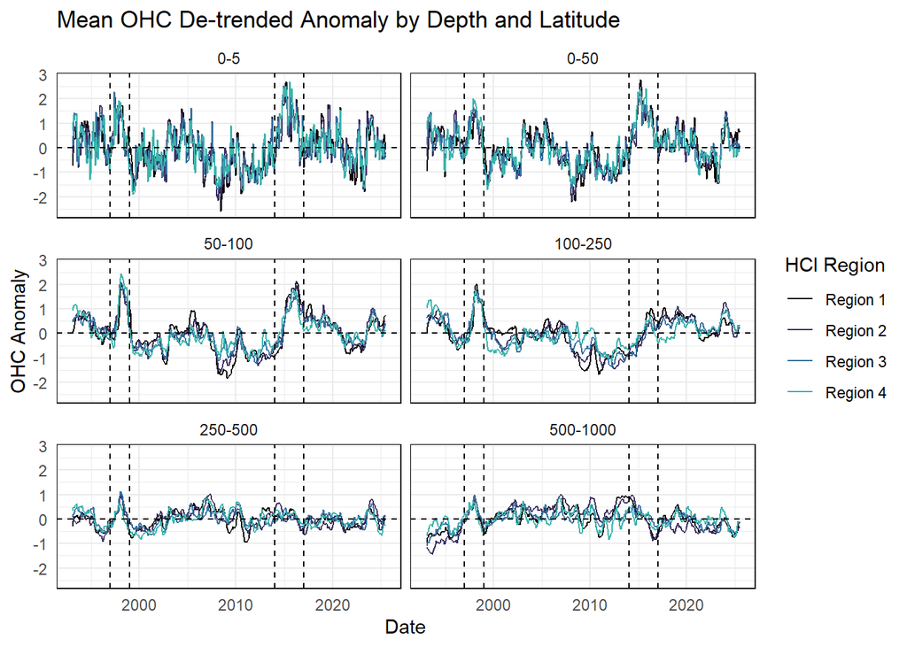

### Correlations

Correlations of this time series among regions and depths.

Make a plot of the correlations

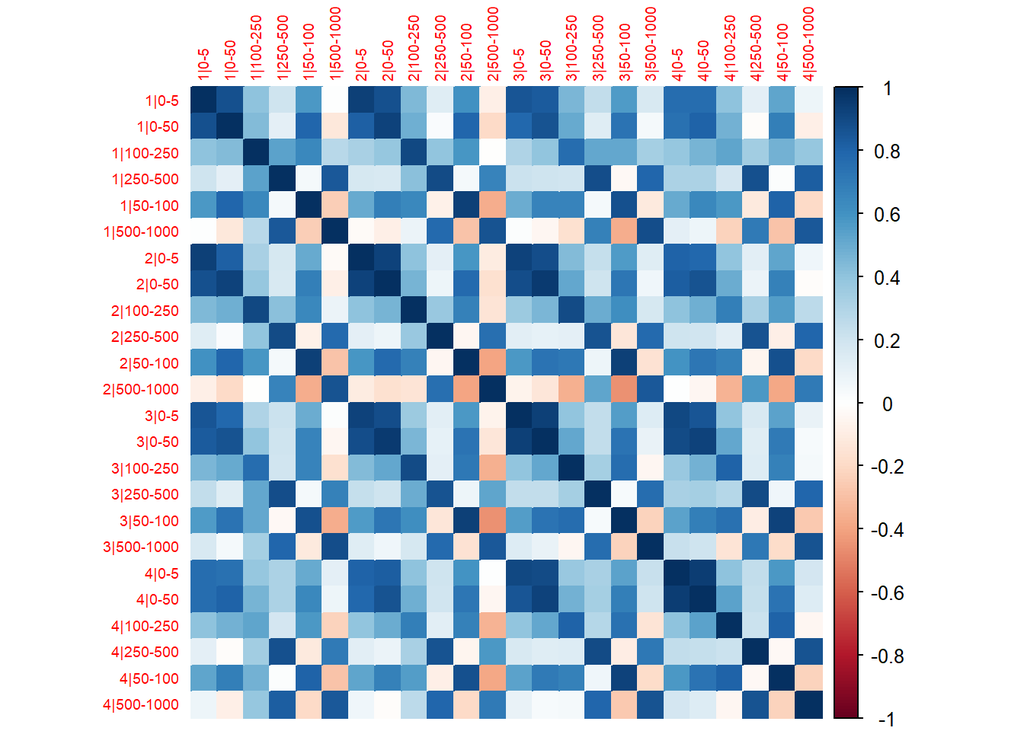

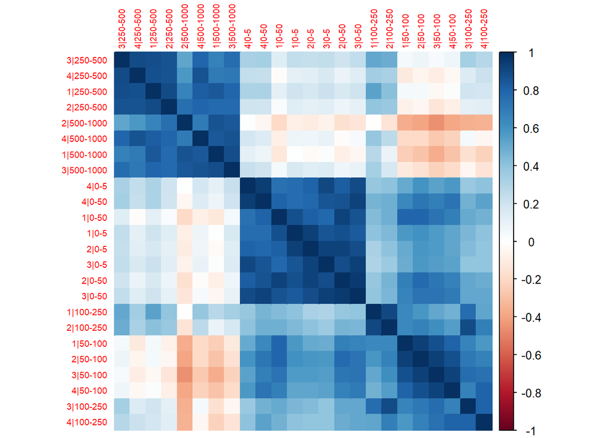

## Heatwave Area

We can also calculate heatwave area. In our case, we’ll define heatwave area as the total (summed) area of any grid cells in a given time step that have an anomaly value greater than 1; that is, the total area greater than 1 SD above the long-term, monthly climatology.

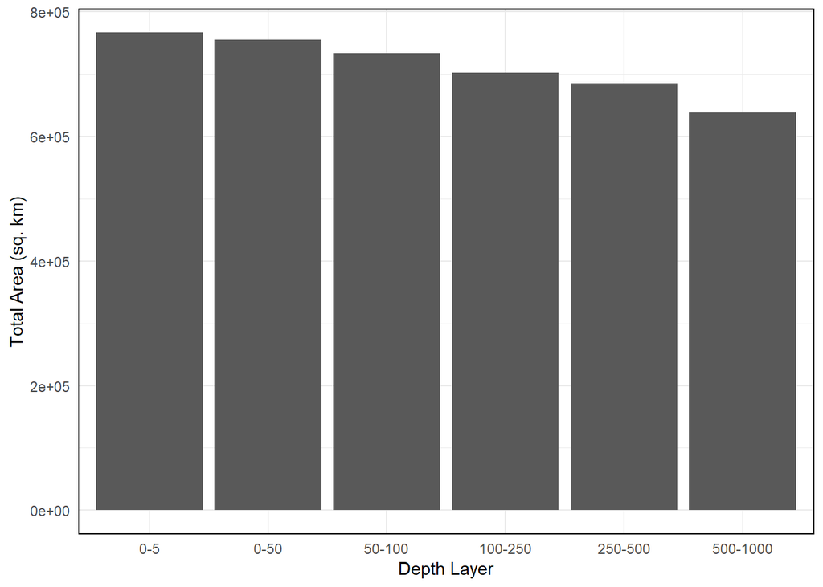

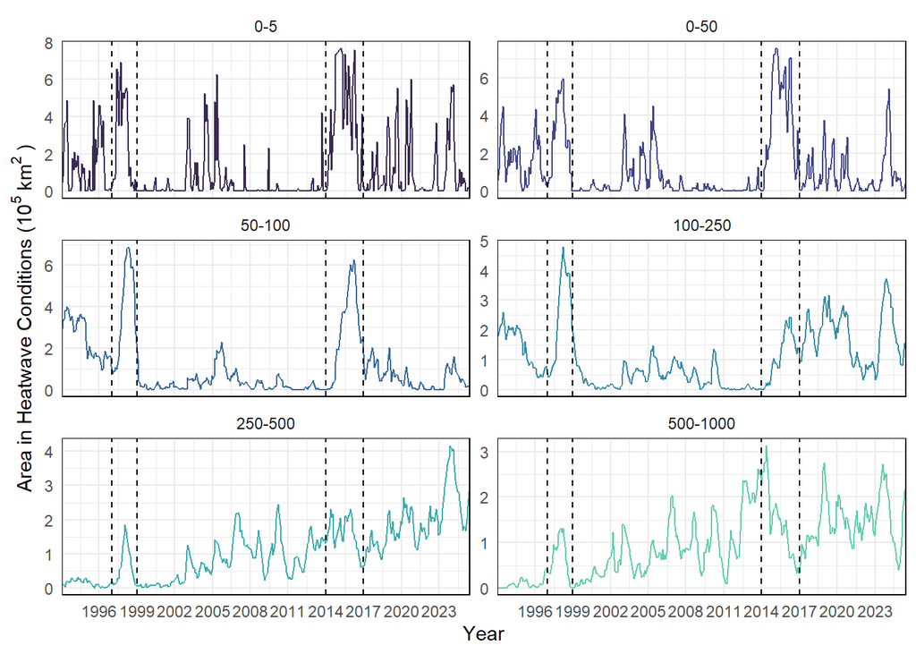

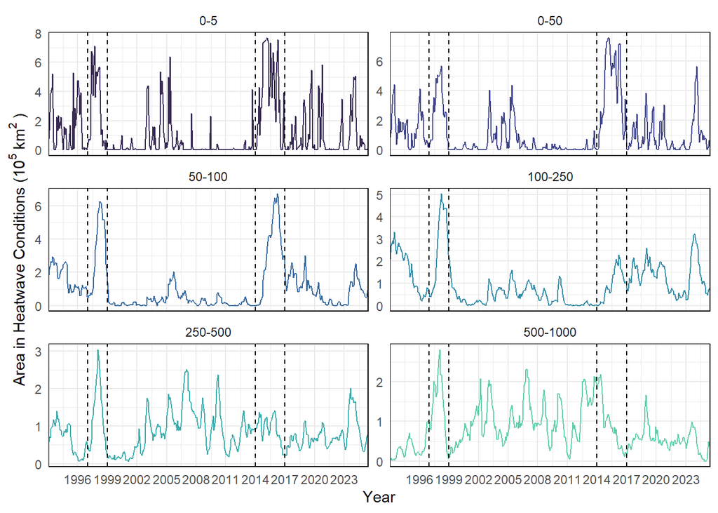

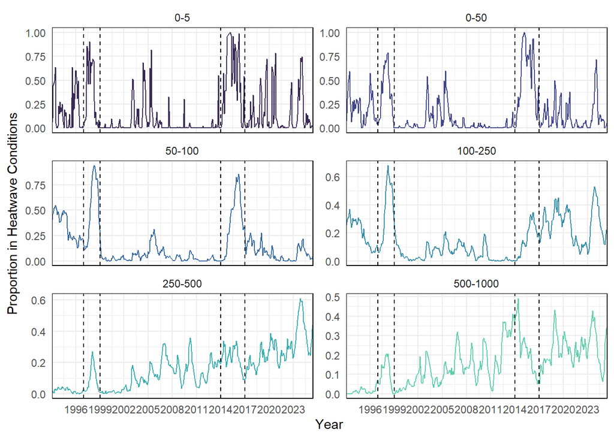

## Consistent Spatial Pattern

Find areas that consistently are affected by heatwave conditions, in total and by month. First we look at frequency- how many months did each pixel exceed the threshold of 1SD above the climatological mean?

Total months in heatwave conditions, across the entire dataset, for each depth layer

Same as above, but calculated by month. For each month, calculate the number of years in heatwave conditions for each pixel.

We can define hotspots as anywhere that has repeatedly had heatwaves

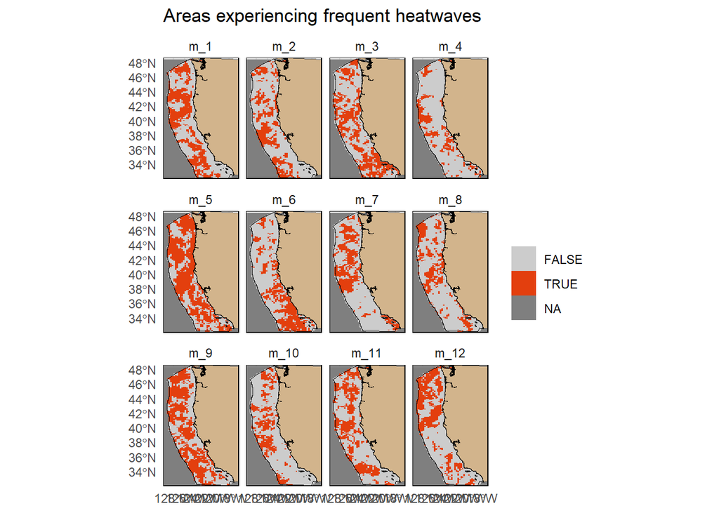

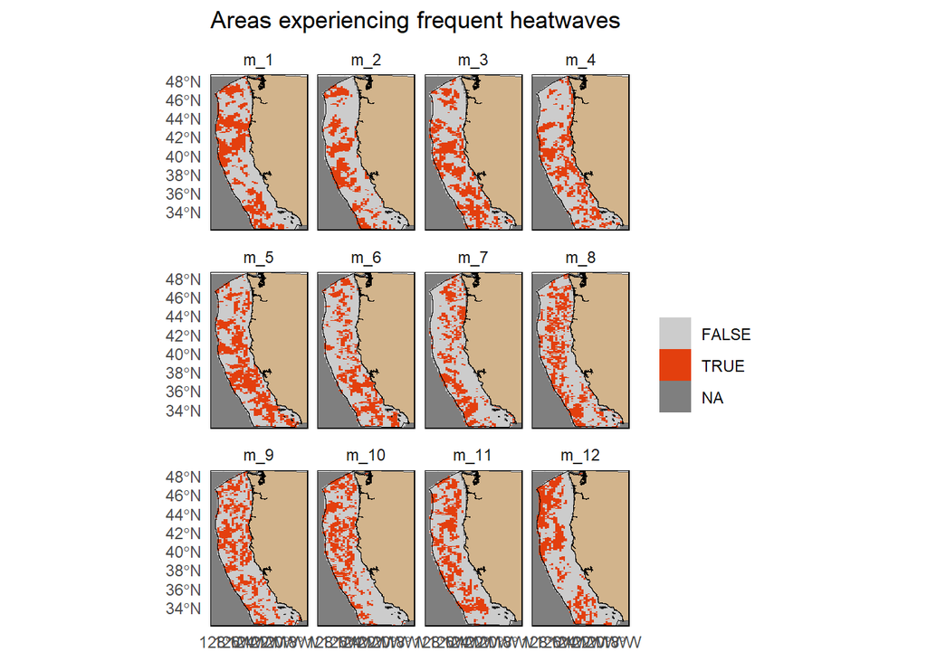

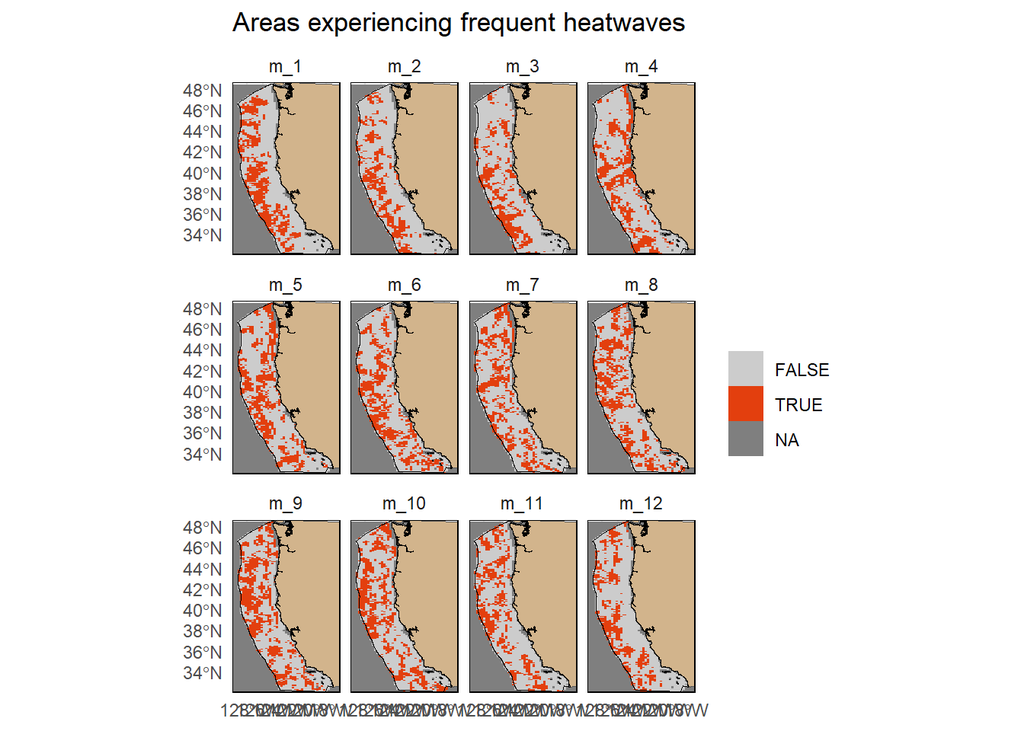

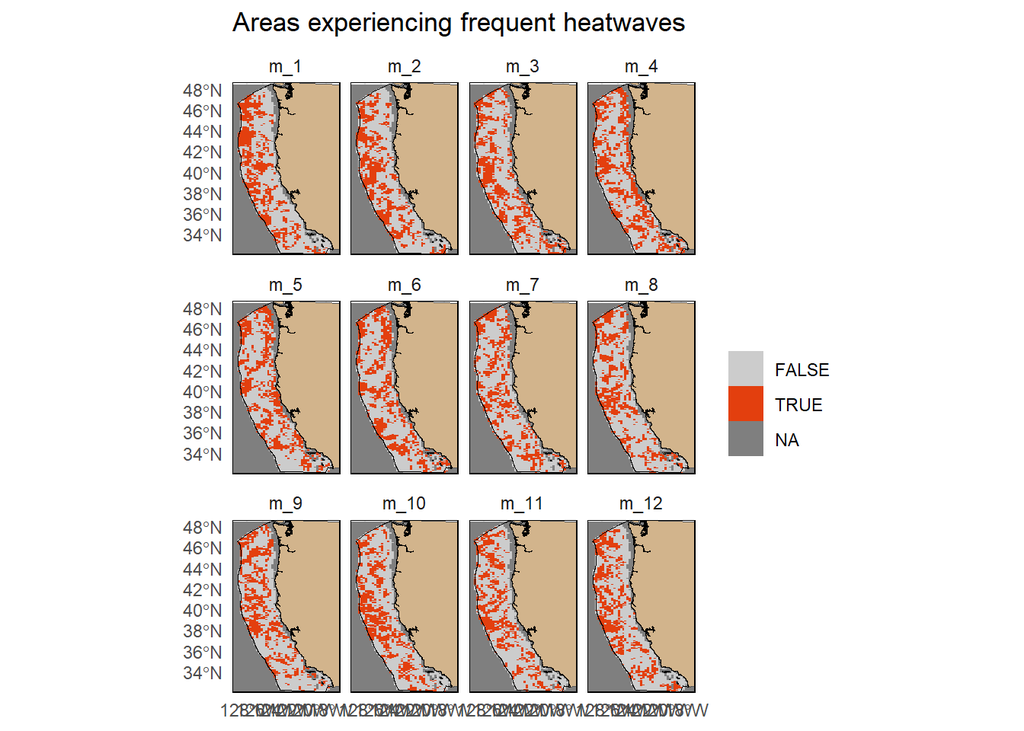

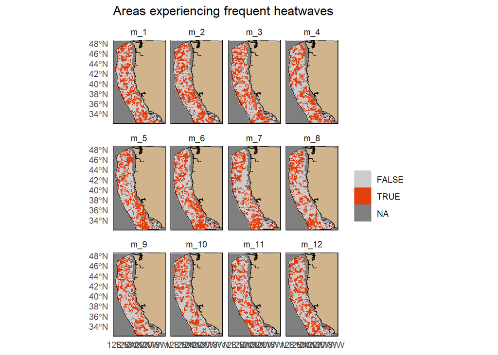

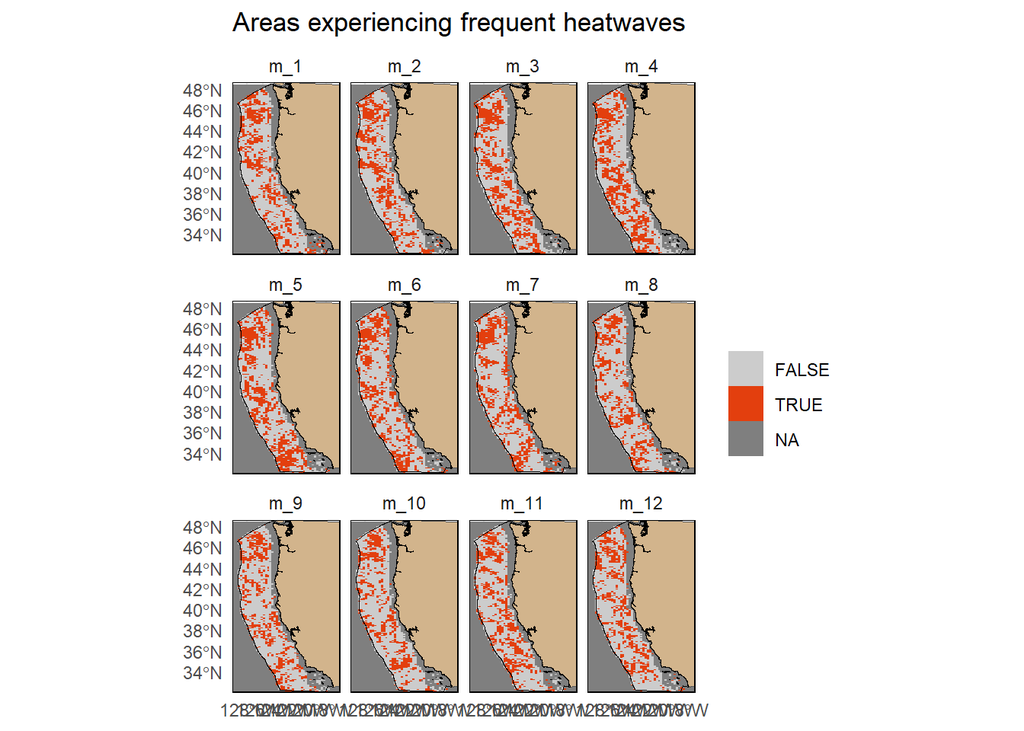

Conversely, we can define coolspots as anywhere that has NOT had many heatwaves

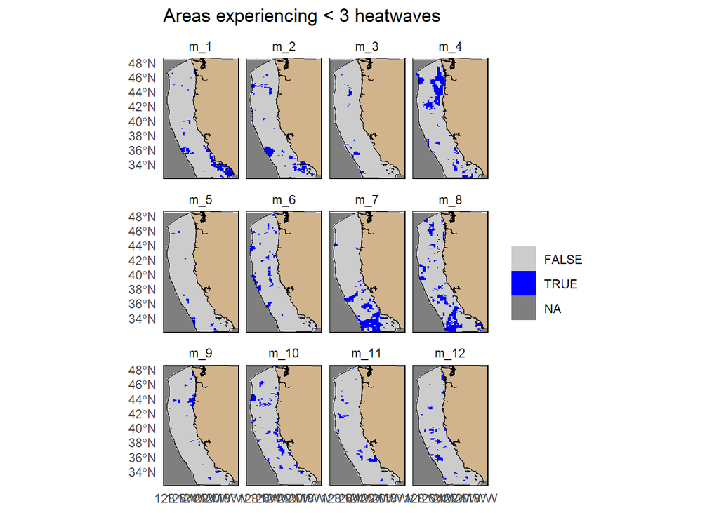

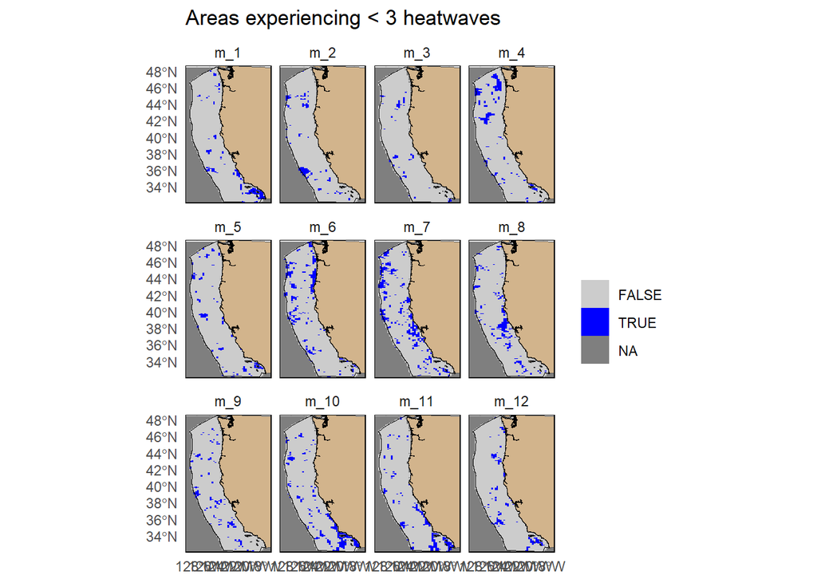

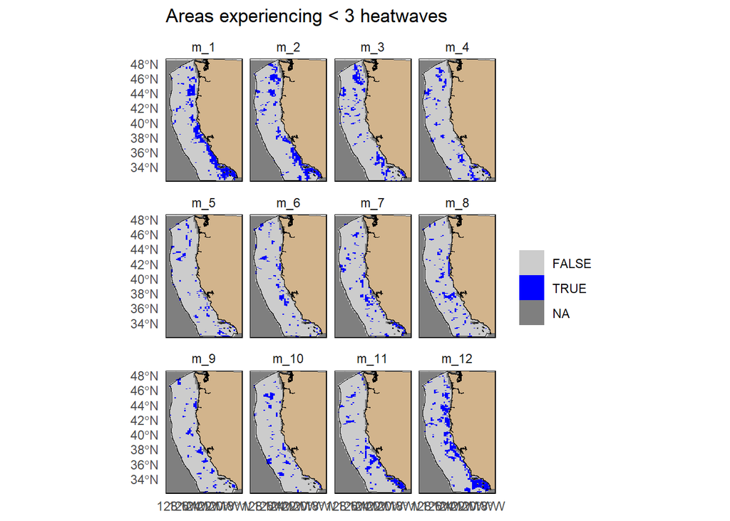

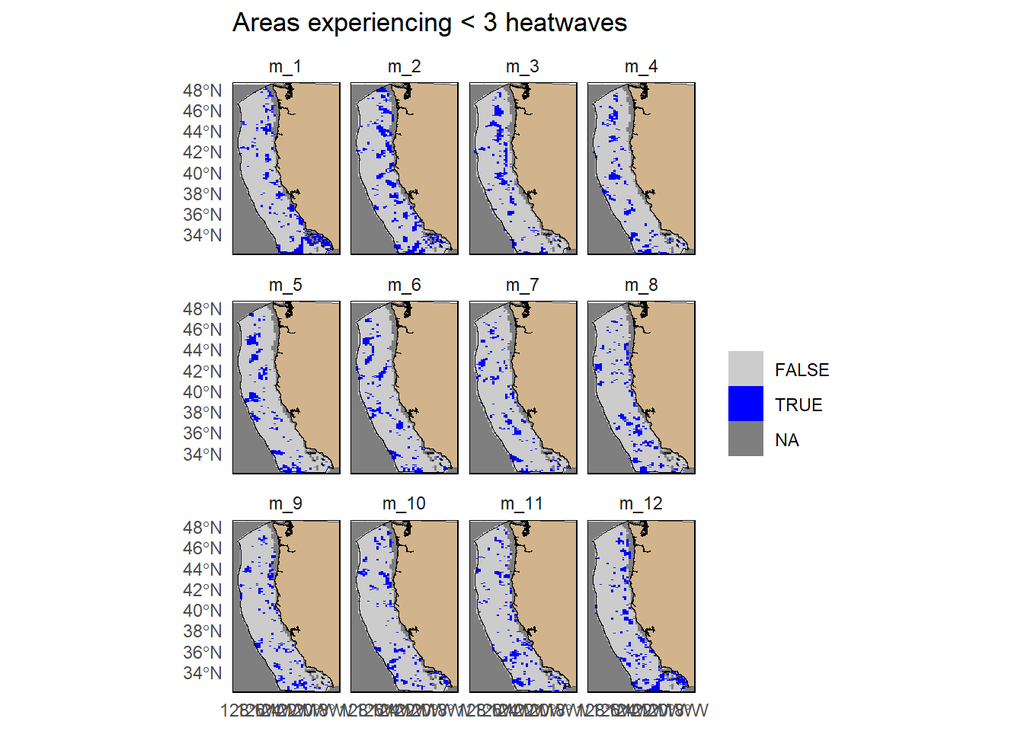

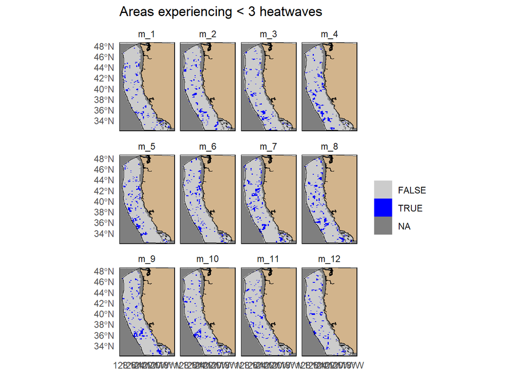

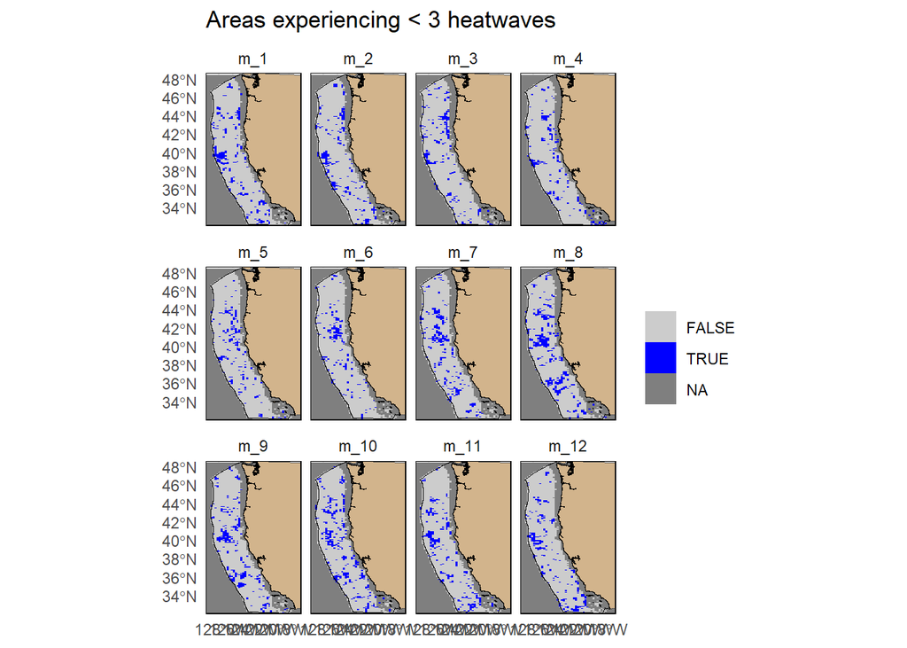

What if we only count positive anomalies (heatwave intensity)? This calculates the accumulated sum (across years) of all positive anomalies in each pixel.

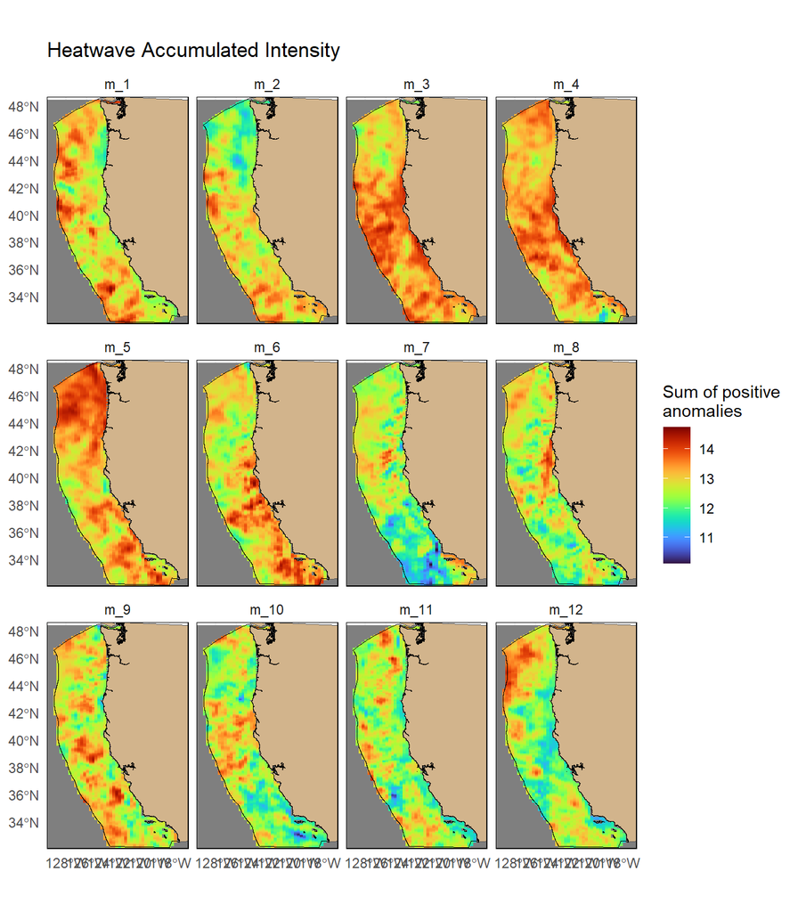

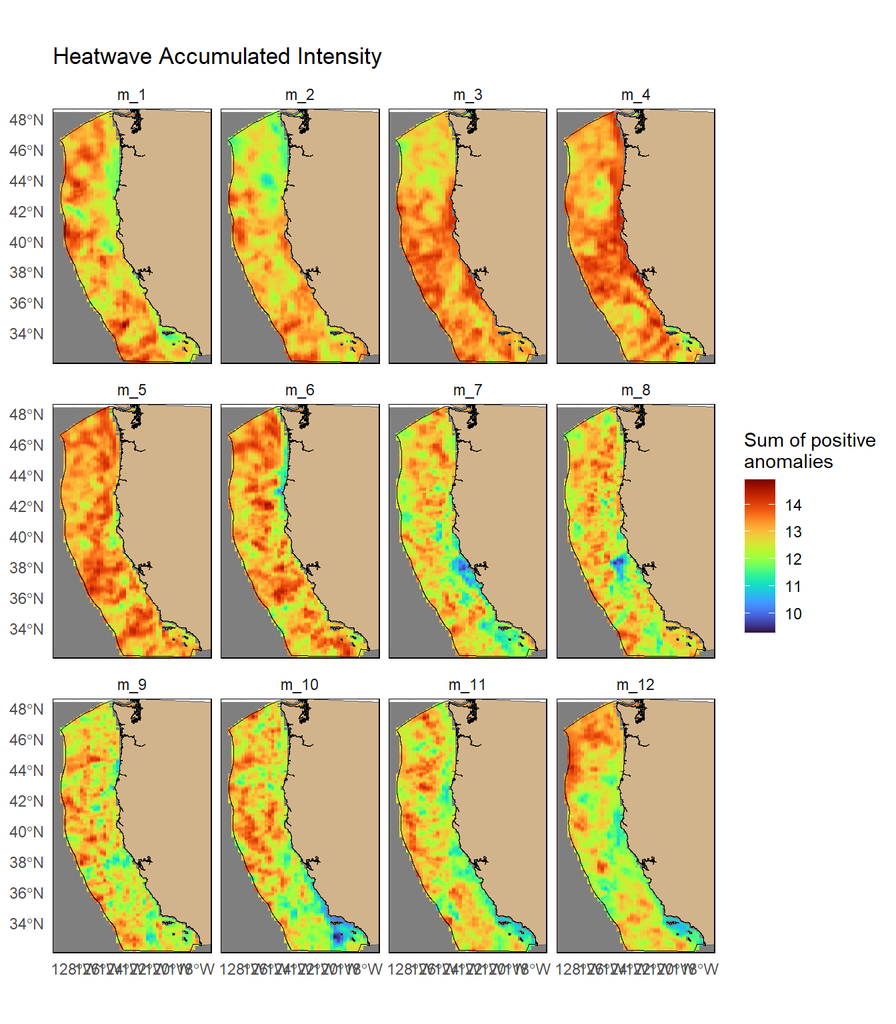

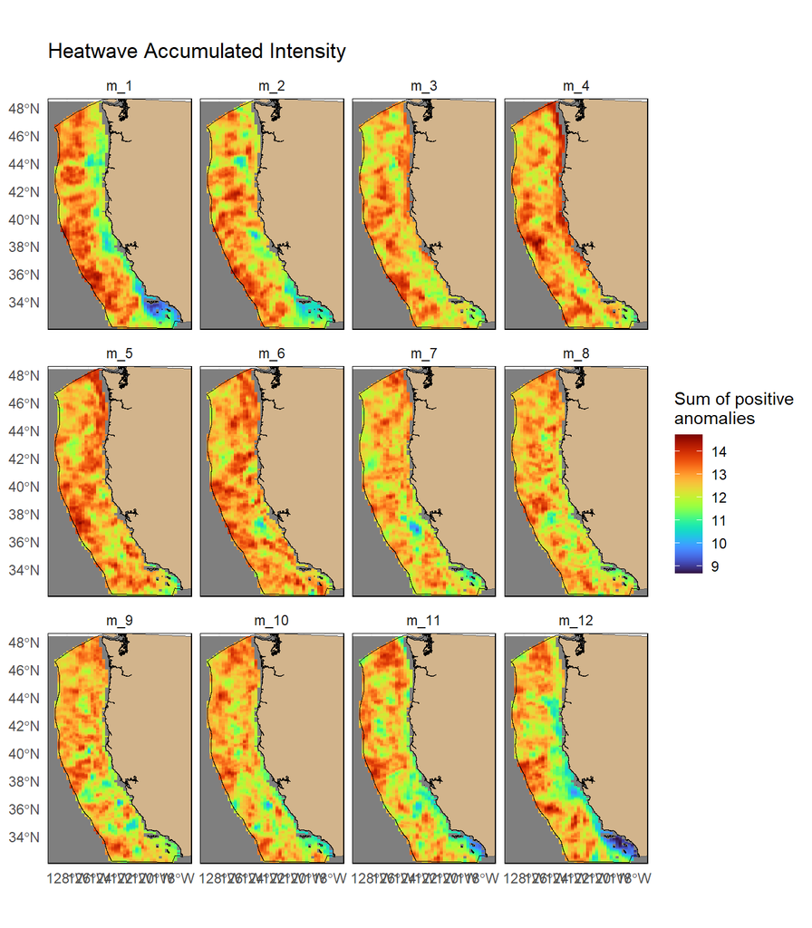